# The relative efficacy of best management practices recommended for grassland bird conservation

Results from our re-analysis

We moved from our previous analysis method, which relied on the *meta* package, and was a bit of black box, to a more straightforward and transparent Bayesian mixed model approach. This allowed us to address some of the reviewers concerns and gave us more flexibility in model construction. Models include the fixed effect of the BMP and random effects of study, effect size ID, and species (where appropriate).

Important changes from the previous version include:

- **Species classification**: This was the biggest change. Shrub species were dropped and we ensured that there was no overlap between guild associations (see [Species classification](https://docs.google.com/spreadsheets/d/12Z5YWPevo1q_IQZbYri-G1M-rJUAsOwJ3eO8f8uyvTY/edit?usp=sharing)). All species were able to be classified based on a published (e.g., Vickery 1999) or widely used (e.g., Partners in Flight) source (*Note: All About Birds and VGBI is in the table but was not the final determinant of classification for the analysis.*).
- **Added Nest success ~ Delay Hay papers**: We added three more papers for this category as only two had made it through our filter previously. Unfortunately, only one of the added three made it through the filter this time!
- **New apples-to-apples pass**: We did an additional filtering pass to ensure that the treatment, control, and response adequately represented the intended BMP. This reduced the sample size but should increase our confidence in the results.
- **Repaired inconsistencies in the sign of the effect**: There were a few cases in which the sign of an effect was incorrect (e.g., nest depredation rate treated as nest success or studies in which the control represented the BMP). Fixed.
- **Some filtered studies were able to be included**: Several studies that were previously omitted (e.g., due to unclear sample sizes or type of statistical test run) were revisited and passed the filter on this round.
- **Log hazard ratio for nest success**: This allowed us to better combine different measures of nest success (e.g., DSR and nest survival) given that exposure period is unknown. We flipped the sign such that positive values represent lower mortality.

# 1 Key takeaways

Abundance, overall

Abundance is estimated for each practice within each guild, and for the guilds pooled where a practice is estimable in both. 2 of 11 pooled practice cells clear zero.

Strongest practice for abundance

**Install Nest-Boxes**, g = 0.60 (0.00 to 1.20), pooled across guilds, followed by **Eliminate Pesticides**, g = 0.36 (-0.01 to 0.73).

Nest success

Nest survival is reported on the log hazard scale and by guild only. 1 of 3 obligate practice cells and 0 of 1 facultative cells clear zero.

Species richness

**Eliminate Pesticides**, g = 0.83 (0.05 to 1.60) leads on species richness, ahead of **Exclude Livestock From Streams and Plant Vegetative Buffers**, g = 0.31 (-0.25 to 0.85). 1 of 7 practices clear zero.

Do the guilds differ?

Obligate and facultative grassland birds differ measurably for 2 of the 8 practice-by-response contrasts tested.

What the evidence rests on

104 papers contribute 941 effect sizes covering 101 species and 11 management practices.

# 2 Sampling overview

The analysis pool is the set of effect sizes that survived conversion, sign-checking and the inclusion thresholds. Papers contribute to more than one response, so the per-response counts below are not additive.

104

Papers

941

Effect sizes

101

Species

11

Practices

Table 1: Analysis pool by response. Abundance carries most of the evidence; nest success is the thinnest pool and its intervals are correspondingly wide.

| Response | Effect sizes | Papers | Species | Practices |
| --- | --- | --- | --- | --- |
| Species richness | 117 | 35 | 14 | 7 |
| Abundance | 787 | 74 | 88 | 10 |
| Nest success | 37 | 16 | 14 | 3 |

Table 2: Effect sizes contributed by each management practice, split by response. Practices with too few effect sizes or studies for a given response are not modeled for that response.

| Practice | Species richness | Abundance | Nest success | All responses |
| --- | --- | --- | --- | --- |
| Implement Prescribed Fire | 23 | 266 | 0 | 289 |
| Plant Native Grasses and Forbs | 13 | 133 | 16 | 162 |
| Promote Edge and Shrub Habitat | 18 | 99 | 14 | 131 |
| Provide Overwintering Structure and Resources | 26 | 66 | 0 | 92 |
| Eliminate Pesticides | 14 | 67 | 0 | 81 |
| Remove Non-native Shrubs | 0 | 60 | 0 | 60 |
| Rotate Livestock Between Pastures | 11 | 35 | 0 | 46 |
| Reduce Grazing Intensity | 0 | 26 | 0 | 26 |
| Exclude Livestock From Streams and Plant Vegetative Buffers | 12 | 12 | 0 | 24 |
| Manage Fields in Patches | 0 | 23 | 0 | 23 |
| Avoid Haying During Nesting Season | 0 | 0 | 7 | 7 |

**How to read this.** A practice with a handful of effect sizes from two or three papers is estimated with strong shrinkage towards the overall mean, so its estimate sits closer to the average than its own data alone would put it. The counts above are the best guide to how much weight any single cell carries.

## 2.1 Draft of the ROSES (inspired) flow diagram

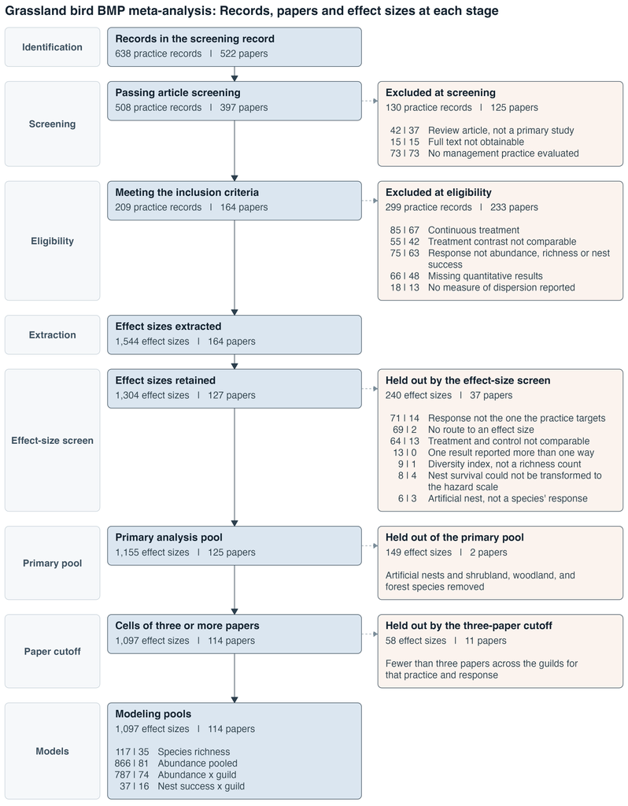

Figure 1: Papers, practice records and effect sizes retained and removed at each stage of the review, from the screening record through to the modeling pools. Practice records are paper x practice rows, so a paper contributing to two practices is counted twice until extraction.

# 3 Species richness

As species richness is an assemblage-level response, it is not partitioned by guild. **Eliminate Pesticides**, g = 0.83 (0.05 to 1.60) leads, then **Exclude Livestock From Streams and Plant Vegetative Buffers**, g = 0.31 (-0.25 to 0.85). 1 of 7 practices clear zero.

Table 3: Species richness by management practice, strongest first.

| Practice | Effect (95% CrI) | P(benefit) | Effect sizes | Studies |
| --- | --- | --- | --- | --- |
| Eliminate Pesticides | 0.83 (0.05, 1.60) | 0.98 | 14 | 7 |
| Exclude Livestock From Streams and Plant Vegetative Buffers | 0.31 (-0.25, 0.85) | 0.87 | 12 | 4 |
| Plant Native Grasses and Forbs | 0.28 (-0.23, 0.78) | 0.87 | 13 | 8 |
| Provide Overwintering Structure and Resources | 0.28 (-0.22, 0.76) | 0.87 | 26 | 7 |
| Promote Edge and Shrub Habitat | 0.27 (-0.23, 0.75) | 0.86 | 18 | 7 |
| Implement Prescribed Fire | 0.13 (-0.68, 0.92) | 0.63 | 23 | 6 |
| Rotate Livestock Between Pastures | -0.33 (-1.21, 0.55) | 0.23 | 11 | 5 |

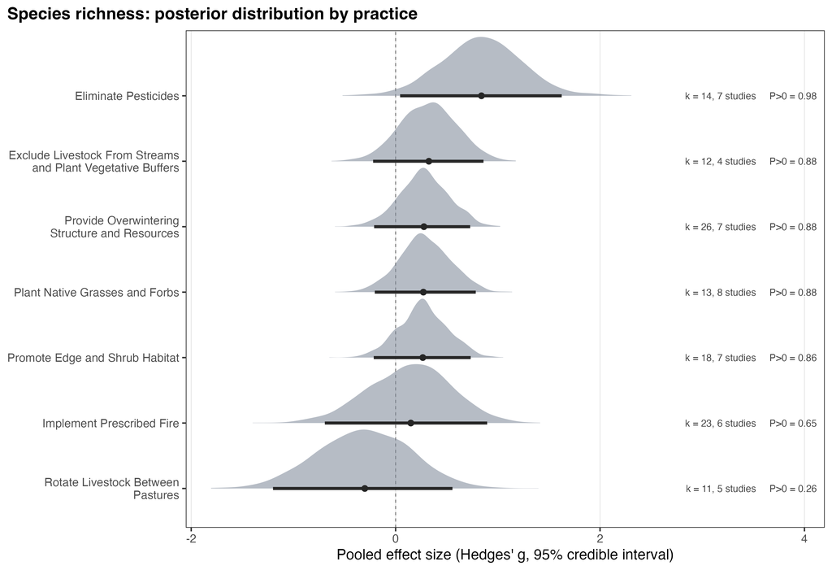

Figure 2: Species richness by management practice. The shaded density behind each row is that cell’s full posterior, scaled to a common height; the point and bar are its median and 95% credible interval. Annotations give the number of effect sizes, the contributing studies, and the posterior probability that the effect is positive.

**Note**: Richness includes all species observed at the study sites, not filtered by facultative and obligtate grassland. While several studies *did* provide richness of classes like *farmland bird indicator species* the majority did not. We should decide whether to subset despite a big loss in sample size.

# 4 Abundance

Abundance is the best-sampled response in the review. It is estimated separately for each guild and, for the practices estimable in both guilds, with the guilds pooled.

## 4.1 Pooled across guilds

Treating obligate and facultative grassland birds as one assemblage, 2 of 11 practices clear zero. The strongest is **Install Nest-Boxes**, g = 0.60 (0.00 to 1.20).

Table 4: Abundance by practice, pooled across obligate and facultative grassland birds.

| Practice | Effect (95% CrI) | P(benefit) | Effect sizes | Studies |
| --- | --- | --- | --- | --- |
| Install Nest-Boxes | 0.60 (0.00, 1.20) | 0.98 | 10 | 4 |
| Eliminate Pesticides | 0.36 (-0.01, 0.73) | 0.97 | 72 | 9 |
| Reduce Grazing Intensity | 0.32 (-0.05, 0.68) | 0.96 | 26 | 5 |
| Manage Fields in Patches | 0.28 (-0.10, 0.65) | 0.93 | 28 | 5 |
| Plant Native Grasses and Forbs | 0.23 (0.01, 0.45) | 0.98 | 133 | 19 |
| Provide Overwintering Structure and Resources | 0.13 (-0.15, 0.40) | 0.82 | 73 | 7 |
| Remove Non-native Shrubs | 0.12 (-0.20, 0.45) | 0.78 | 67 | 4 |
| Exclude Livestock From Streams and Plant Vegetative Buffers | 0.12 (-0.21, 0.45) | 0.77 | 52 | 3 |
| Implement Prescribed Fire | 0.06 (-0.16, 0.28) | 0.70 | 267 | 19 |
| Rotate Livestock Between Pastures | 0.05 (-0.37, 0.48) | 0.59 | 35 | 5 |
| Promote Edge and Shrub Habitat | -0.03 (-0.25, 0.19) | 0.41 | 103 | 16 |

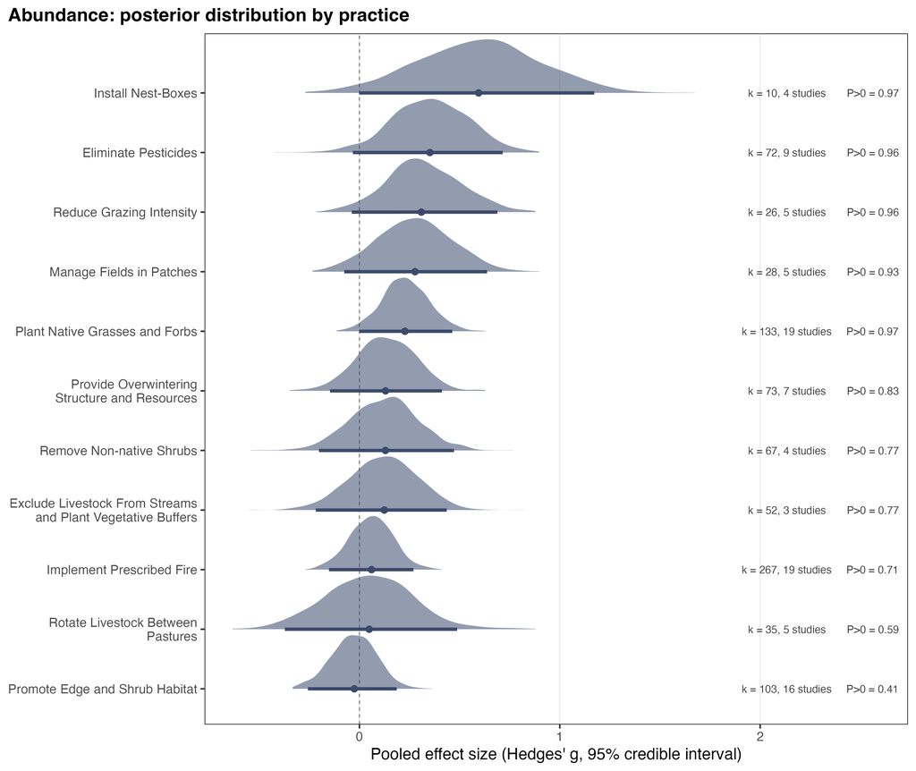

Figure 3: Abundance response to each practice, pooled across both guilds. The shaded density behind each row is that cell’s full posterior, scaled to a common height; the point and bar are its median and 95% credible interval.

## 4.2 By guild

Estimated separately for each guild: 4 of 9 obligate cells clear zero, and 2 of 8 facultative cells.

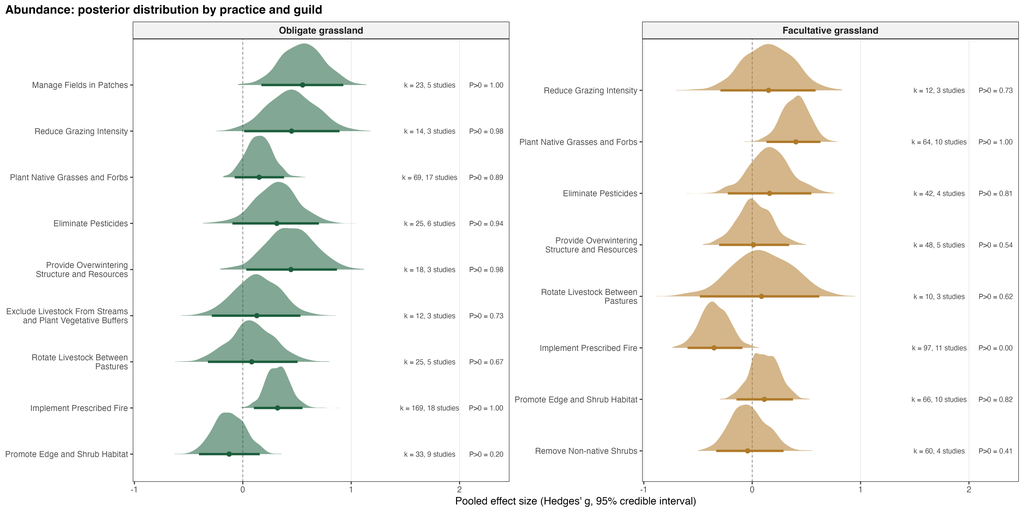

Figure 4: Abundance response to each practice, obligate grassland birds on the left and facultative on the right. Each guild is estimated separately, so a practice appears in a panel only where it has a cell. The shaded density behind each row is that cell’s full posterior, scaled to a common height; the point and bar are its median and 95% credible interval.

## 4.3 Obligate grassland birds

By practice, 4 of 9 obligate cells clear zero; the strongest is **Manage Fields in Patches**, g = 0.56 (0.19 to 0.93).

Table 5: Abundance by practice, obligate grassland birds only.

| Practice | Effect (95% CrI) | P(benefit) | Effect sizes | Studies |
| --- | --- | --- | --- | --- |
| Manage Fields in Patches | 0.56 (0.19, 0.93) | 1.00 | 23 | 5 |
| Reduce Grazing Intensity | 0.45 (0.03, 0.89) | 0.98 | 14 | 3 |
| Provide Overwintering Structure and Resources | 0.44 (0.02, 0.86) | 0.98 | 18 | 3 |
| Implement Prescribed Fire | 0.32 (0.10, 0.54) | 1.00 | 169 | 18 |
| Eliminate Pesticides | 0.30 (-0.09, 0.69) | 0.94 | 25 | 6 |
| Plant Native Grasses and Forbs | 0.15 (-0.08, 0.40) | 0.89 | 69 | 17 |
| Exclude Livestock From Streams and Plant Vegetative Buffers | 0.13 (-0.27, 0.54) | 0.74 | 12 | 3 |
| Rotate Livestock Between Pastures | 0.08 (-0.31, 0.48) | 0.65 | 25 | 5 |
| Promote Edge and Shrub Habitat | -0.12 (-0.40, 0.16) | 0.20 | 33 | 9 |

*Note: For “Grazing Intensity” the treatment is low intensity and the control is high. This was only used if the authors of the original paper treated it as a categorical variable.*

## 4.4 Facultative grassland birds

By practice, 2 of 8 facultative cells clear zero; the strongest is **Plant Native Grasses and Forbs**, g = 0.39 (0.15 to 0.64).

Table 6: Abundance by practice, facultative grassland birds only.

| Practice | Effect (95% CrI) | P(benefit) | Effect sizes | Studies |
| --- | --- | --- | --- | --- |
| Plant Native Grasses and Forbs | 0.39 (0.15, 0.64) | 1.00 | 64 | 10 |
| Eliminate Pesticides | 0.16 (-0.23, 0.54) | 0.80 | 42 | 4 |
| Reduce Grazing Intensity | 0.15 (-0.33, 0.61) | 0.73 | 12 | 3 |
| Promote Edge and Shrub Habitat | 0.11 (-0.14, 0.36) | 0.81 | 66 | 10 |
| Rotate Livestock Between Pastures | 0.09 (-0.45, 0.63) | 0.63 | 10 | 3 |
| Provide Overwintering Structure and Resources | 0.02 (-0.29, 0.33) | 0.56 | 48 | 5 |
| Remove Non-native Shrubs | -0.02 (-0.34, 0.31) | 0.45 | 60 | 4 |
| Implement Prescribed Fire | -0.35 (-0.60, -0.10) | 0.00 | 97 | 11 |

## 4.5 Contrasts between the guilds

Within practice, 2 of 7 obligate-minus-facultative contrasts clear zero on the Hedges’ g scale.

Table 7: Obligate minus facultative, abundance, by practice. P is the posterior probability that the practice benefits obligate species more.

| Practice | Difference (95% CrI) | P(obligate greater) |
| --- | --- | --- |
| Implement Prescribed Fire | 0.67 (0.43, 0.91) | 1.00 |
| Provide Overwintering Structure and Resources | 0.42 (0.03, 0.80) | 0.98 |
| Reduce Grazing Intensity | 0.31 (-0.29, 0.90) | 0.85 |
| Eliminate Pesticides | 0.14 (-0.21, 0.49) | 0.79 |
| Rotate Livestock Between Pastures | -0.01 (-0.52, 0.50) | 0.49 |
| Promote Edge and Shrub Habitat | -0.23 (-0.56, 0.09) | 0.08 |
| Plant Native Grasses and Forbs | -0.24 (-0.52, 0.05) | 0.05 |

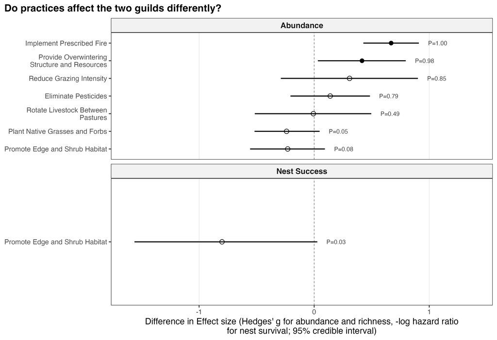

Figure 5: Difference between the guilds, obligate minus facultative, within each practice, for abundance in the upper panel and nest success in the lower. Values above zero mean the practice does more for obligate grassland birds. Points are posterior medians with 95% credible intervals, filled where the interval excludes zero, and P is the posterior probability that the practice benefits obligate species more.

**How to read this.** This is the section to draw recommendations from. Where a guild contrast is clear of zero, the pooled estimate understates the benefit to one guild and overstates it for the other, so read the guild rows rather than the pooled one for those practices.

# 5 Nest success

Nest success is measured on the log hazard scale and rests on far fewer effect sizes than abundance, so intervals are wide throughout. It is reported by guild only; the two guilds are not pooled.

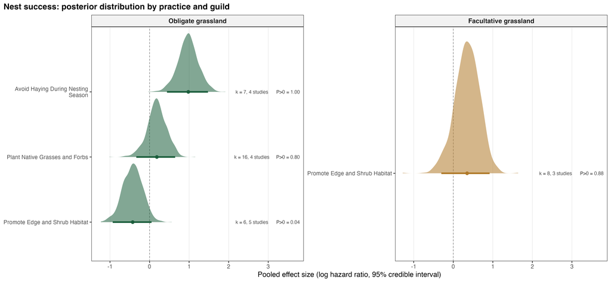

Figure 6: Nest success response to each practice, obligate grassland birds on the left and facultative on the right. Each guild is estimated separately, so a practice appears in a panel only where it has a cell. The shaded density behind each row is that cell’s full posterior, scaled to a common height; the point and bar are its median and 95% credible interval.

## 5.1 Obligate grassland birds

By practice, 1 of 3 obligate cells clear zero.

Table 8: Nest success by practice, obligate grassland birds only.

| Practice | Effect (95% CrI) | P(benefit) | Effect sizes | Studies |
| --- | --- | --- | --- | --- |
| Avoid Haying During Nesting Season | 0.98 (0.45, 1.51) | 1.00 | 7 | 4 |
| Plant Native Grasses and Forbs | 0.18 (-0.32, 0.66) | 0.79 | 16 | 4 |
| Promote Edge and Shrub Habitat | -0.44 (-0.96, 0.08) | 0.05 | 6 | 5 |

## 5.2 Facultative grassland birds

By practice, 0 of 1 facultative cells clear zero.

Table 9: Nest success by practice, facultative grassland birds only.

| Practice | Effect (95% CrI) | P(benefit) | Effect sizes | Studies |
| --- | --- | --- | --- | --- |
| Promote Edge and Shrub Habitat | 0.37 (-0.28, 0.93) | 0.88 | 8 | 3 |

## 5.3 Contrasts between the guilds

Within practice, 0 of 1 obligate-minus-facultative contrasts clear zero.

Table 10: Obligate minus facultative, nest success, by practice. P is the posterior probability that the practice benefits obligate species more.

| Practice | Difference (95% CrI) | P(obligate greater) |
| --- | --- | --- |
| Promote Edge and Shrub Habitat | -0.80 (-1.56, 0.03) | 0.03 |

**How to read this.** Nest survival rests on a fraction of the abundance evidence, and the intervals show it. Read the intervals rather than the point estimates, and treat a single practice clearing zero as a lead worth following rather than a settled finding.

# 6 Sensitivity and robustness

Every model family was refitted under each alternative specification, and the refitted cell means compared with the primary ones. A conclusion counts as changed when an interval that excluded zero no longer does, or the reverse. Publication bias is tested separately, by regressing study-aggregated effect sizes on their standard errors. The tables below read what `scripts/analysis/6_sensitivity.R` wrote; nothing on this page refits a model.

Refitting ran under europe dropped, flagged effects removed, great plains dropped, great plains only, group means only, guild assigned only, most influential study removed, non grassland classes retained, one effect per study cell, outliers removed, paper floor four, paper floor two, southeast us dropped, tighter priors and wider priors. Across 493 refitted cells, 42 changed conclusion. The largest median shift in a point estimate was 0.44 (most influential study removed, species richness, by practice).

Table 11: Effect of each alternative specification on each model family. Guild and Pooled carry practice as a random effect; the practice models estimate a mean per cell. Cells is the number of cell means refitted; median shift is the median absolute change in the point estimate.

| Specification | Response | Model | Cells | Conclusions changed | Median shift |
| --- | --- | --- | --- | --- | --- |
| Europe dropped | Abundance | Guild x practice | 16 | 0 | 0.01 |
| Europe dropped | Abundance | Pooled x practice | 10 | 0 | 0.01 |
| Europe dropped | Nest success | Guild x practice | 3 | 0 | 0.01 |
| Europe dropped | Species richness | By practice | 7 | 1 | 0.01 |
| Flagged effects removed | Abundance | Guild x practice | 17 | 0 | 0.00 |
| Flagged effects removed | Abundance | Pooled x practice | 11 | 1 | 0.00 |
| Flagged effects removed | Nest success | Guild x practice | 4 | 0 | 0.00 |
| Flagged effects removed | Species richness | By practice | 7 | 0 | 0.14 |
| Great Plains dropped | Abundance | Guild x practice | 12 | 2 | 0.07 |
| Great Plains dropped | Abundance | Pooled x practice | 9 | 1 | 0.07 |
| Great Plains dropped | Nest success | Guild x practice | 3 | 0 | 0.04 |
| Great Plains dropped | Species richness | By practice | 7 | 0 | 0.16 |
| Great Plains only | Abundance | Guild x practice | 6 | 4 | 0.09 |
| Great Plains only | Abundance | Pooled x practice | 3 | 1 | 0.05 |
| Group means only | Abundance | Guild x practice | 14 | 1 | 0.01 |
| Group means only | Abundance | Pooled x practice | 10 | 1 | 0.03 |
| Group means only | Nest success | Guild x practice | 4 | 0 | 0.01 |
| Group means only | Species richness | By practice | 7 | 1 | 0.01 |
| Guild assigned only | Abundance | Guild x practice | 17 | 0 | 0.00 |
| Guild assigned only | Abundance | Pooled x practice | 10 | 1 | 0.01 |
| Guild assigned only | Nest success | Guild x practice | 4 | 0 | 0.00 |
| Guild assigned only | Species richness | By practice | 7 | 0 | 0.00 |
| Most influential study removed | Abundance | Guild x practice | 4 | 1 | 0.17 |
| Most influential study removed | Abundance | Pooled x practice | 2 | 1 | 0.29 |
| Most influential study removed | Nest success | Guild x practice | 1 | 0 | 0.22 |
| Most influential study removed | Species richness | By practice | 1 | 1 | 0.44 |
| Non grassland classes retained | Abundance | Guild x practice | 17 | 0 | 0.00 |
| Non grassland classes retained | Abundance | Pooled x practice | 11 | 2 | 0.03 |
| Non grassland classes retained | Nest success | Guild x practice | 4 | 0 | 0.00 |
| Non grassland classes retained | Species richness | By practice | 7 | 0 | 0.01 |
| One effect per study cell | Abundance | Guild x practice | 17 | 5 | 0.14 |
| One effect per study cell | Abundance | Pooled x practice | 11 | 1 | 0.08 |
| One effect per study cell | Nest success | Guild x practice | 4 | 0 | 0.08 |
| One effect per study cell | Species richness | By practice | 7 | 0 | 0.01 |
| Outliers removed | Abundance | Guild x practice | 15 | 1 | 0.07 |
| Outliers removed | Abundance | Pooled x practice | 11 | 4 | 0.05 |
| Outliers removed | Nest success | Guild x practice | 4 | 2 | 0.17 |
| Outliers removed | Species richness | By practice | 7 | 0 | 0.12 |
| Paper floor four | Abundance | Guild x practice | 12 | 0 | 0.03 |
| Paper floor four | Abundance | Pooled x practice | 10 | 1 | 0.01 |
| Paper floor four | Nest success | Guild x practice | 3 | 0 | 0.08 |
| Paper floor four | Species richness | By practice | 7 | 0 | 0.00 |
| Paper floor two | Abundance | Guild x practice | 17 | 0 | 0.00 |
| Paper floor two | Abundance | Pooled x practice | 11 | 0 | 0.00 |
| Paper floor two | Nest success | Guild x practice | 4 | 0 | 0.00 |
| Paper floor two | Species richness | By practice | 7 | 0 | 0.00 |
| Southeast US dropped | Abundance | Guild x practice | 14 | 2 | 0.04 |
| Southeast US dropped | Abundance | Pooled x practice | 9 | 2 | 0.03 |
| Southeast US dropped | Nest success | Guild x practice | 3 | 0 | 0.08 |
| Southeast US dropped | Species richness | By practice | 7 | 1 | 0.02 |
| Tighter priors | Abundance | Guild x practice | 17 | 2 | 0.03 |
| Tighter priors | Abundance | Pooled x practice | 11 | 1 | 0.02 |
| Tighter priors | Nest success | Guild x practice | 4 | 0 | 0.05 |
| Tighter priors | Species richness | By practice | 7 | 1 | 0.11 |
| Wider priors | Abundance | Guild x practice | 17 | 0 | 0.01 |
| Wider priors | Abundance | Pooled x practice | 11 | 0 | 0.01 |
| Wider priors | Nest success | Guild x practice | 4 | 0 | 0.01 |
| Wider priors | Species richness | By practice | 7 | 0 | 0.05 |

## 6.1 Which conclusions changed

Of the cells refitted, 42 changed conclusion: 8 received more support under an alternative specification, 34 were clear in the primary analysis and lost support, and 0 changed sign.

Table 12: Every cell whose conclusion changed under an alternative specification, strongest shift first. Gained means the interval excludes zero under the alternative but not in the primary analysis; lost means the reverse; reversed means the alternative both excludes zero and carries the opposite sign. Estimates are on the scale of the response concerned.

| Change | Specification | Response | Model | Guild | Practice | Primary | Refitted (95% CrI) | Shift |
| --- | --- | --- | --- | --- | --- | --- | --- | --- |
| Lost | Outliers removed | Abundance | Pooled x practice | All grassland birds | Install Nest-Boxes | 0.60 | 0.03 (-0.48, 0.51) | -0.57 |
| Lost | Most influential study removed | Abundance | Pooled x practice | All grassland birds | Install Nest-Boxes | 0.60 | 0.04 (-0.58, 0.65) | -0.56 |
| Lost | Great Plains only | Abundance | Guild x practice | Facultative grassland | Plant Native Grasses and Forbs | 0.39 | -0.12 (-0.70, 0.46) | -0.51 |
| Lost | Most influential study removed | Species richness | By practice | — | Eliminate Pesticides | 0.83 | 0.40 (-0.24, 1.04) | -0.44 |
| Lost | Europe dropped | Species richness | By practice | — | Eliminate Pesticides | 0.83 | 0.47 (-0.45, 1.39) | -0.36 |
| Lost | Great Plains dropped | Abundance | Guild x practice | Facultative grassland | Implement Prescribed Fire | -0.35 | -0.04 (-0.45, 0.38) | 0.31 |
| Lost | One effect per study cell | Abundance | Guild x practice | Facultative grassland | Plant Native Grasses and Forbs | 0.39 | 0.11 (-0.22, 0.42) | -0.29 |
| Lost | One effect per study cell | Abundance | Guild x practice | Obligate grassland | Reduce Grazing Intensity | 0.45 | 0.17 (-0.44, 0.77) | -0.28 |
| Lost | Great Plains only | Abundance | Pooled x practice | All grassland birds | Plant Native Grasses and Forbs | 0.23 | -0.04 (-0.39, 0.33) | -0.27 |
| Lost | Tighter priors | Species richness | By practice | — | Eliminate Pesticides | 0.83 | 0.59 (-0.05, 1.19) | -0.25 |
| Lost | One effect per study cell | Abundance | Guild x practice | Facultative grassland | Implement Prescribed Fire | -0.35 | -0.12 (-0.46, 0.22) | 0.23 |
| Lost | Most influential study removed | Abundance | Guild x practice | Obligate grassland | Implement Prescribed Fire | 0.32 | 0.12 (-0.10, 0.35) | -0.20 |
| Lost | One effect per study cell | Abundance | Guild x practice | Obligate grassland | Implement Prescribed Fire | 0.32 | 0.15 (-0.10, 0.40) | -0.17 |
| Lost | Southeast US dropped | Abundance | Guild x practice | Facultative grassland | Plant Native Grasses and Forbs | 0.39 | 0.25 (-0.01, 0.52) | -0.14 |
| Lost | Great Plains only | Abundance | Guild x practice | Obligate grassland | Manage Fields in Patches | 0.56 | 0.43 (-0.08, 0.92) | -0.13 |
| Lost | Tighter priors | Abundance | Pooled x practice | All grassland birds | Install Nest-Boxes | 0.60 | 0.47 (-0.05, 0.99) | -0.13 |
| Lost | Group means only | Abundance | Guild x practice | Obligate grassland | Manage Fields in Patches | 0.56 | 0.44 (-0.11, 0.98) | -0.12 |
| Lost | One effect per study cell | Abundance | Guild x practice | Obligate grassland | Provide Overwintering Structure and Resources | 0.44 | 0.52 (-0.07, 1.11) | 0.08 |
| Lost | Group means only | Species richness | By practice | — | Eliminate Pesticides | 0.83 | 0.91 (-0.15, 1.94) | 0.08 |
| Lost | Great Plains dropped | Abundance | Guild x practice | Obligate grassland | Implement Prescribed Fire | 0.32 | 0.24 (-0.10, 0.61) | -0.07 |
| Lost | Southeast US dropped | Abundance | Pooled x practice | All grassland birds | Plant Native Grasses and Forbs | 0.23 | 0.15 (-0.07, 0.38) | -0.07 |
| Lost | Tighter priors | Abundance | Guild x practice | Obligate grassland | Reduce Grazing Intensity | 0.45 | 0.38 (-0.02, 0.78) | -0.07 |
| Lost | Southeast US dropped | Abundance | Guild x practice | Obligate grassland | Reduce Grazing Intensity | 0.45 | 0.39 (-0.04, 0.82) | -0.06 |
| Lost | Tighter priors | Abundance | Guild x practice | Obligate grassland | Provide Overwintering Structure and Resources | 0.44 | 0.38 (-0.01, 0.76) | -0.06 |
| Lost | Non grassland classes retained | Abundance | Pooled x practice | All grassland birds | Plant Native Grasses and Forbs | 0.23 | 0.18 (-0.03, 0.39) | -0.05 |
| Lost | One effect per study cell | Abundance | Pooled x practice | All grassland birds | Plant Native Grasses and Forbs | 0.23 | 0.27 (-0.00, 0.56) | 0.05 |
| Lost | Great Plains dropped | Abundance | Pooled x practice | All grassland birds | Install Nest-Boxes | 0.60 | 0.64 (-0.02, 1.31) | 0.04 |
| Lost | Great Plains only | Abundance | Guild x practice | Facultative grassland | Implement Prescribed Fire | -0.35 | -0.31 (-0.75, 0.14) | 0.04 |
| Lost | Guild assigned only | Abundance | Pooled x practice | All grassland birds | Plant Native Grasses and Forbs | 0.23 | 0.19 (-0.02, 0.40) | -0.04 |
| Lost | Group means only | Abundance | Pooled x practice | All grassland birds | Plant Native Grasses and Forbs | 0.23 | 0.19 (-0.02, 0.41) | -0.04 |
| Lost | Great Plains only | Abundance | Guild x practice | Obligate grassland | Implement Prescribed Fire | 0.32 | 0.29 (-0.09, 0.63) | -0.03 |
| Lost | Paper floor four | Abundance | Pooled x practice | All grassland birds | Install Nest-Boxes | 0.60 | 0.61 (-0.00, 1.22) | 0.01 |
| Lost | Southeast US dropped | Species richness | By practice | — | Eliminate Pesticides | 0.83 | 0.83 (-0.04, 1.65) | -0.01 |
| Lost | Flagged effects removed | Abundance | Pooled x practice | All grassland birds | Install Nest-Boxes | 0.60 | 0.60 (-0.00, 1.21) | 0.00 |
| Gained | Outliers removed | Nest success | Guild x practice | Facultative grassland | Promote Edge and Shrub Habitat | 0.37 | 0.73 (0.18, 1.13) | 0.36 |
| Gained | Outliers removed | Abundance | Pooled x practice | All grassland birds | Manage Fields in Patches | 0.28 | 0.42 (0.09, 0.76) | 0.15 |
| Gained | Outliers removed | Abundance | Guild x practice | Facultative grassland | Eliminate Pesticides | 0.16 | 0.30 (0.00, 0.59) | 0.14 |
| Gained | Outliers removed | Nest success | Guild x practice | Obligate grassland | Promote Edge and Shrub Habitat | -0.44 | -0.56 (-1.02, -0.13) | -0.12 |
| Gained | Outliers removed | Abundance | Pooled x practice | All grassland birds | Eliminate Pesticides | 0.36 | 0.32 (0.05, 0.59) | -0.04 |
| Gained | Non grassland classes retained | Abundance | Pooled x practice | All grassland birds | Eliminate Pesticides | 0.36 | 0.35 (0.00, 0.69) | -0.01 |
| Gained | Southeast US dropped | Abundance | Pooled x practice | All grassland birds | Eliminate Pesticides | 0.36 | 0.37 (0.03, 0.71) | 0.01 |
| Gained | Outliers removed | Abundance | Pooled x practice | All grassland birds | Reduce Grazing Intensity | 0.32 | 0.31 (0.02, 0.61) | -0.00 |

## 6.2 Records held out by the data-quality screen

The flagged-records specification holds out 11 extraction records from 8 studies. Its row in the table above says what the pooled estimates look like without them.

Table 13: Studies contributing records that the data-quality screen could not clear. Records stay in the primary analysis and are held out only under the flagged-records specification; each carries its evidence in the project data-quality register.

| Study | Records | Screen flags |
| --- | --- | --- |
| Raynor et al. 2017 | 3 | implausibly precise se; zero dispersion reported |
| Lautenbach et al. 2020 | 2 | identical arm values across contrasts |
| Davis et al. 2020b | 1 | zero dispersion reported |
| George et al. 2013 | 1 | implausibly precise se |
| Gowdy et al. 2022 | 1 | duplicate extraction row |
| Pirez and Aldabe 2023 | 1 | link scale se reported |
| Port and Schottler 2017 | 1 | implausibly precise se |
| Willcox et al. 2010 | 1 | implausibly precise se |

Egger tests were run on 4 analysis pools, of which 0 show funnel asymmetry at p < 0.05. Each guild is tested on its own, because aggregation leaves a study one observation in each and a test spanning both would carry that study twice. Pools with fewer than 10 studies once effect sizes are aggregated within study are reported without a test.

Table 14: Egger regression tests for funnel asymmetry, run on effect sizes aggregated within study. PET and PEESE give the bias-adjusted mean the same aggregated data imply, for comparison with the pooled estimate.

| Analysis | Guild | Studies | Pooled estimate | Egger statistic | p | Asymmetry | PET | PEESE |
| --- | --- | --- | --- | --- | --- | --- | --- | --- |
| abundance | Obligate grassland | 59 | 0.14 | 0.43 | 0.672 | No | 0.08 | 0.09 |
| abundance | Facultative grassland | 44 | 0.13 | 0.42 | 0.676 | No | 0.04 | 0.06 |
| species richness | — | 35 | 0.33 | 0.26 | 0.797 | No | 0.25 | 0.26 |
| nest success | Obligate grassland | 13 | 0.16 | -0.47 | 0.648 | No | 0.52 | 0.46 |
| nest success | Facultative grassland | 3 | — | — | — | — | — | — |

# 7 Supplemental figures and tables

Supplemental: Species-level response

# 8 Species-level responses

Species-level estimates are partially pooled: a species with few effect sizes is shrunk towards its guild mean rather than estimated in isolation. Species with fewer than 3 effect sizes are not shown. The strongest responder overall is **Mountain plover**, g = 0.60 (0.14 to 1.18).

## 8.1 Averaged over practices

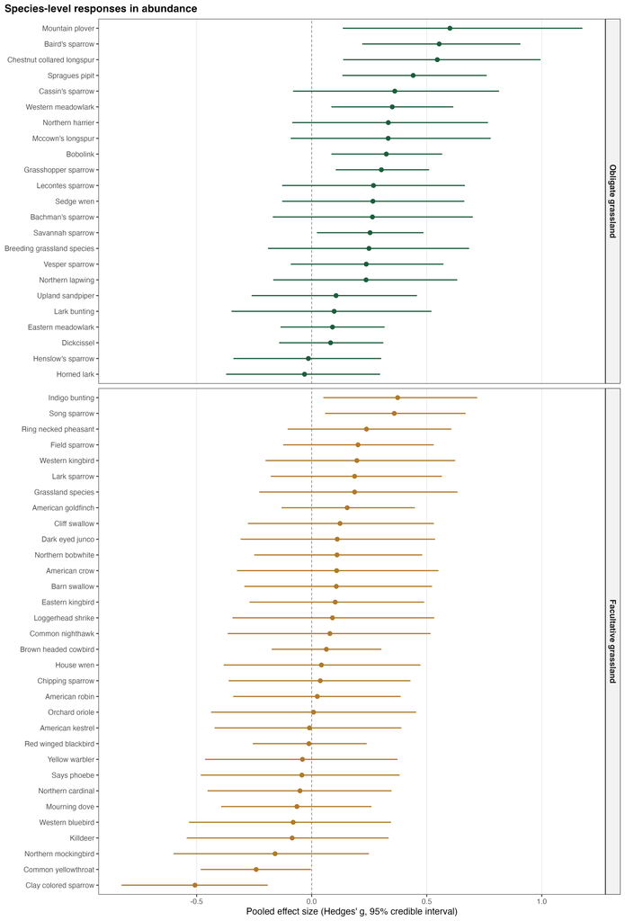

Figure 7: Abundance response by species, obligate grassland birds in the upper panel and facultative in the lower. Estimates are partially pooled towards the guild mean, so a species with little data sits close to the guild average with a wide interval. Points are posterior medians with 95% credible intervals.

Table 15: Abundance response by species averaged over practices, strongest first.

| Species | Effect (95% CrI) | P(benefit) | Effect sizes | Studies |
| --- | --- | --- | --- | --- |
| Mountain plover | 0.60 (0.14, 1.18) | 0.99 | 3 | 1 |
| Baird’s sparrow | 0.55 (0.22, 0.91) | 1.00 | 9 | 2 |
| Chestnut collared longspur | 0.55 (0.14, 0.99) | 1.00 | 6 | 4 |
| Spragues pipit | 0.44 (0.13, 0.76) | 1.00 | 12 | 3 |
| Indigo bunting | 0.37 (0.05, 0.72) | 0.99 | 13 | 7 |
| Cassin’s sparrow | 0.36 (-0.08, 0.81) | 0.95 | 3 | 2 |
| Song sparrow | 0.36 (0.06, 0.67) | 0.99 | 22 | 9 |
| Western meadowlark | 0.35 (0.09, 0.62) | 0.99 | 25 | 13 |
| Northern harrier | 0.33 (-0.08, 0.77) | 0.94 | 4 | 2 |
| Mccown’s longspur | 0.33 (-0.09, 0.78) | 0.94 | 4 | 2 |
| Bobolink | 0.32 (0.09, 0.57) | 1.00 | 36 | 16 |
| Grasshopper sparrow | 0.30 (0.10, 0.51) | 1.00 | 63 | 31 |
| Lecontes sparrow | 0.27 (-0.13, 0.67) | 0.91 | 4 | 2 |
| Sedge wren | 0.27 (-0.13, 0.66) | 0.91 | 7 | 3 |
| Bachman’s sparrow | 0.26 (-0.17, 0.70) | 0.89 | 3 | 2 |
| Savannah sparrow | 0.25 (0.02, 0.49) | 0.98 | 38 | 17 |
| Breeding grassland species | 0.25 (-0.19, 0.68) | 0.87 | 6 | 1 |
| Ring necked pheasant | 0.24 (-0.10, 0.61) | 0.91 | 14 | 4 |
| Vesper sparrow | 0.24 (-0.09, 0.57) | 0.92 | 10 | 7 |
| Northern lapwing | 0.24 (-0.17, 0.63) | 0.88 | 4 | 2 |
| Field sparrow | 0.20 (-0.12, 0.53) | 0.89 | 11 | 8 |
| Western kingbird | 0.20 (-0.20, 0.62) | 0.83 | 7 | 2 |
| Lark sparrow | 0.19 (-0.18, 0.57) | 0.84 | 10 | 6 |
| Grassland species | 0.19 (-0.23, 0.63) | 0.81 | 6 | 3 |
| American goldfinch | 0.15 (-0.13, 0.45) | 0.86 | 22 | 11 |
| Cliff swallow | 0.12 (-0.28, 0.53) | 0.73 | 6 | 2 |
| Dark eyed junco | 0.11 (-0.31, 0.54) | 0.70 | 4 | 3 |
| Northern bobwhite | 0.11 (-0.25, 0.48) | 0.72 | 11 | 7 |
| American crow | 0.11 (-0.32, 0.55) | 0.69 | 3 | 3 |
| Barn swallow | 0.11 (-0.29, 0.52) | 0.71 | 6 | 2 |
| Upland sandpiper | 0.11 (-0.26, 0.46) | 0.72 | 10 | 4 |
| Eastern kingbird | 0.10 (-0.27, 0.49) | 0.70 | 7 | 5 |
| Lark bunting | 0.10 (-0.35, 0.52) | 0.67 | 5 | 3 |
| Loggerhead shrike | 0.09 (-0.34, 0.53) | 0.66 | 3 | 2 |
| Eastern meadowlark | 0.09 (-0.14, 0.32) | 0.79 | 48 | 22 |
| Dickcissel | 0.08 (-0.14, 0.31) | 0.76 | 50 | 24 |
| Common nighthawk | 0.08 (-0.37, 0.52) | 0.64 | 3 | 2 |
| Brown headed cowbird | 0.06 (-0.17, 0.30) | 0.70 | 38 | 15 |
| House wren | 0.04 (-0.38, 0.47) | 0.58 | 3 | 2 |
| Chipping sparrow | 0.04 (-0.36, 0.43) | 0.57 | 5 | 4 |
| American robin | 0.02 (-0.34, 0.39) | 0.56 | 9 | 4 |
| Orchard oriole | 0.01 (-0.44, 0.45) | 0.51 | 4 | 1 |
| American kestrel | -0.01 (-0.42, 0.39) | 0.48 | 5 | 3 |
| Red winged blackbird | -0.01 (-0.26, 0.24) | 0.46 | 40 | 16 |
| Henslow’s sparrow | -0.01 (-0.34, 0.30) | 0.47 | 18 | 6 |
| Horned lark | -0.03 (-0.37, 0.30) | 0.43 | 12 | 8 |
| Yellow warbler | -0.04 (-0.46, 0.37) | 0.42 | 4 | 3 |
| Says phoebe | -0.04 (-0.48, 0.38) | 0.42 | 3 | 2 |
| Northern cardinal | -0.05 (-0.45, 0.35) | 0.40 | 7 | 2 |
| Mourning dove | -0.06 (-0.39, 0.26) | 0.35 | 18 | 9 |
| Western bluebird | -0.08 (-0.53, 0.34) | 0.35 | 3 | 2 |
| Killdeer | -0.08 (-0.54, 0.33) | 0.35 | 4 | 4 |
| Northern mockingbird | -0.16 (-0.60, 0.25) | 0.22 | 7 | 3 |
| Common yellowthroat | -0.24 (-0.48, -0.00) | 0.02 | 38 | 15 |
| Clay colored sparrow | -0.51 (-0.83, -0.19) | 0.00 | 17 | 4 |

## 8.2 Response by practice

Species enters the models as an additive random intercept and is never crossed with practice, so there is no modeled species-by-practice cell to report: the model would simply shift every species by the same amount within a practice. What follows is the **observed** evidence instead — the raw effect sizes for each species-by-practice cell combined by inverse-variance weighting, with no partial pooling and no shrinkage towards a guild mean. Cells need at least 3 effect sizes from 2 studies to appear. Read these as what the literature reports, not as model estimates: a cell resting on three effect sizes from two papers can move a long way on one new study.

71 species-by-practice cells clear those thresholds, covering 31 species across 9 practices.

Table 16: Observed abundance response by species and practice, strongest first.

| Species | Practice | Guild | Effect | Effect sizes | Studies |
| --- | --- | --- | --- | --- | --- |
| Grasshopper sparrow | Manage Fields in Patches | Obligate grassland | 1.23 (0.73, 1.73) | 5 | 3 |
| Eastern meadowlark | Eliminate Pesticides | Obligate grassland | 1.20 (0.64, 1.76) | 3 | 2 |
| Bobolink | Manage Fields in Patches | Obligate grassland | 1.06 (0.43, 1.69) | 4 | 2 |
| Lark sparrow | Implement Prescribed Fire | Facultative grassland | 1.01 (0.15, 1.88) | 3 | 2 |
| Grasshopper sparrow | Reduce Grazing Intensity | Obligate grassland | 0.98 (0.70, 1.27) | 3 | 2 |
| Song sparrow | Provide Overwintering Structure and Resources | Facultative grassland | 0.95 (0.42, 1.48) | 3 | 2 |
| Indigo bunting | Plant Native Grasses and Forbs | Facultative grassland | 0.90 (0.58, 1.23) | 5 | 2 |
| Red winged blackbird | Eliminate Pesticides | Facultative grassland | 0.73 (0.27, 1.19) | 4 | 2 |
| Western meadowlark | Implement Prescribed Fire | Obligate grassland | 0.68 (0.49, 0.86) | 13 | 5 |
| Indigo bunting | Promote Edge and Shrub Habitat | Facultative grassland | 0.62 (0.09, 1.14) | 3 | 2 |
| Savannah sparrow | Provide Overwintering Structure and Resources | Obligate grassland | 0.55 (0.07, 1.04) | 3 | 2 |
| Field sparrow | Plant Native Grasses and Forbs | Facultative grassland | 0.53 (0.41, 0.66) | 4 | 3 |
| Grassland species | Reduce Grazing Intensity | Facultative grassland | 0.53 (0.04, 1.02) | 4 | 2 |
| Bobolink | Eliminate Pesticides | Obligate grassland | 0.52 (0.05, 0.98) | 4 | 2 |
| Bobolink | Implement Prescribed Fire | Obligate grassland | 0.52 (0.36, 0.67) | 17 | 4 |
| Song sparrow | Plant Native Grasses and Forbs | Facultative grassland | 0.51 (0.38, 0.64) | 7 | 3 |
| Song sparrow | Eliminate Pesticides | Facultative grassland | 0.48 (0.03, 0.94) | 4 | 2 |
| Common yellowthroat | Plant Native Grasses and Forbs | Facultative grassland | 0.46 (0.33, 0.58) | 10 | 6 |
| American goldfinch | Eliminate Pesticides | Facultative grassland | 0.44 (-0.00, 0.89) | 4 | 2 |
| Savannah sparrow | Implement Prescribed Fire | Obligate grassland | 0.43 (0.26, 0.60) | 13 | 2 |
| Savannah sparrow | Promote Edge and Shrub Habitat | Obligate grassland | 0.41 (-0.11, 0.93) | 3 | 2 |
| Dark eyed junco | Provide Overwintering Structure and Resources | Facultative grassland | 0.39 (-0.13, 0.91) | 3 | 2 |
| Grasshopper sparrow | Implement Prescribed Fire | Obligate grassland | 0.36 (0.24, 0.48) | 36 | 14 |
| Horned lark | Implement Prescribed Fire | Obligate grassland | 0.34 (-0.25, 0.93) | 3 | 2 |
| Vesper sparrow | Rotate Livestock Between Pastures | Obligate grassland | 0.23 (0.03, 0.44) | 3 | 2 |
| American goldfinch | Plant Native Grasses and Forbs | Facultative grassland | 0.22 (0.10, 0.35) | 6 | 4 |
| Upland sandpiper | Reduce Grazing Intensity | Obligate grassland | 0.22 (-0.05, 0.49) | 3 | 2 |
| Western meadowlark | Plant Native Grasses and Forbs | Obligate grassland | 0.21 (0.07, 0.34) | 5 | 4 |
| Savannah sparrow | Rotate Livestock Between Pastures | Obligate grassland | 0.20 (-0.19, 0.60) | 4 | 3 |
| Brown headed cowbird | Implement Prescribed Fire | Facultative grassland | 0.19 (0.05, 0.34) | 23 | 6 |
| Song sparrow | Promote Edge and Shrub Habitat | Facultative grassland | 0.19 (-0.20, 0.57) | 7 | 3 |
| Clay colored sparrow | Rotate Livestock Between Pastures | Facultative grassland | 0.18 (-0.25, 0.61) | 3 | 2 |
| Sedge wren | Plant Native Grasses and Forbs | Obligate grassland | 0.16 (-0.28, 0.60) | 5 | 3 |
| American kestrel | Provide Overwintering Structure and Resources | Facultative grassland | 0.16 (-0.35, 0.67) | 3 | 2 |
| Eastern meadowlark | Manage Fields in Patches | Obligate grassland | 0.11 (-0.48, 0.71) | 4 | 2 |
| Red winged blackbird | Implement Prescribed Fire | Facultative grassland | 0.11 (-0.19, 0.42) | 13 | 5 |
| Common yellowthroat | Eliminate Pesticides | Facultative grassland | 0.11 (-0.41, 0.62) | 3 | 2 |
| Savannah sparrow | Eliminate Pesticides | Obligate grassland | 0.09 (-0.35, 0.53) | 4 | 2 |
| Indigo bunting | Remove Non-native Shrubs | Facultative grassland | 0.09 (-0.33, 0.50) | 3 | 2 |
| American goldfinch | Promote Edge and Shrub Habitat | Facultative grassland | 0.07 (-0.27, 0.41) | 4 | 3 |
| Red winged blackbird | Plant Native Grasses and Forbs | Facultative grassland | 0.05 (-0.07, 0.18) | 10 | 6 |
| Western meadowlark | Rotate Livestock Between Pastures | Obligate grassland | 0.03 (-0.30, 0.36) | 4 | 3 |
| Bobolink | Plant Native Grasses and Forbs | Obligate grassland | 0.01 (-0.10, 0.13) | 6 | 6 |
| Dickcissel | Plant Native Grasses and Forbs | Obligate grassland | -0.00 (-0.15, 0.15) | 11 | 8 |
| Brown headed cowbird | Remove Non-native Shrubs | Facultative grassland | -0.01 (-0.38, 0.36) | 6 | 3 |
| Northern lapwing | Eliminate Pesticides | Obligate grassland | -0.01 (-0.14, 0.12) | 4 | 2 |
| Northern bobwhite | Implement Prescribed Fire | Facultative grassland | -0.05 (-0.48, 0.38) | 8 | 5 |
| Ring necked pheasant | Plant Native Grasses and Forbs | Facultative grassland | -0.06 (-0.41, 0.29) | 8 | 3 |
| Dickcissel | Implement Prescribed Fire | Obligate grassland | -0.06 (-0.22, 0.10) | 23 | 12 |
| Eastern meadowlark | Implement Prescribed Fire | Obligate grassland | -0.06 (-0.34, 0.21) | 15 | 7 |
| Common yellowthroat | Promote Edge and Shrub Habitat | Facultative grassland | -0.08 (-0.49, 0.32) | 6 | 3 |
| Common yellowthroat | Remove Non-native Shrubs | Facultative grassland | -0.09 (-0.37, 0.20) | 4 | 2 |
| American goldfinch | Implement Prescribed Fire | Facultative grassland | -0.12 (-0.64, 0.39) | 4 | 2 |
| Mourning dove | Implement Prescribed Fire | Facultative grassland | -0.13 (-0.59, 0.32) | 7 | 3 |
| Grasshopper sparrow | Plant Native Grasses and Forbs | Obligate grassland | -0.20 (-0.30, -0.11) | 11 | 9 |
| Bachman’s sparrow | Promote Edge and Shrub Habitat | Obligate grassland | -0.21 (-0.51, 0.10) | 3 | 2 |
| Savannah sparrow | Plant Native Grasses and Forbs | Obligate grassland | -0.22 (-0.32, -0.13) | 10 | 8 |
| Eastern meadowlark | Plant Native Grasses and Forbs | Obligate grassland | -0.23 (-0.33, -0.14) | 12 | 7 |
| Eastern meadowlark | Promote Edge and Shrub Habitat | Obligate grassland | -0.26 (-0.69, 0.17) | 6 | 2 |
| Upland sandpiper | Implement Prescribed Fire | Obligate grassland | -0.26 (-0.59, 0.06) | 6 | 3 |
| Yellow warbler | Remove Non-native Shrubs | Facultative grassland | -0.30 (-0.65, 0.06) | 3 | 2 |
| American robin | Remove Non-native Shrubs | Facultative grassland | -0.37 (-0.68, -0.06) | 5 | 2 |
| Red winged blackbird | Promote Edge and Shrub Habitat | Facultative grassland | -0.43 (-0.86, 0.00) | 6 | 2 |
| Northern cardinal | Remove Non-native Shrubs | Facultative grassland | -0.45 (-0.76, -0.15) | 5 | 2 |
| Henslow’s sparrow | Implement Prescribed Fire | Obligate grassland | -0.48 (-0.74, -0.23) | 13 | 4 |
| Dickcissel | Manage Fields in Patches | Obligate grassland | -0.62 (-1.30, 0.06) | 4 | 2 |
| Field sparrow | Implement Prescribed Fire | Facultative grassland | -0.64 (-1.34, 0.07) | 3 | 2 |
| Grasshopper sparrow | Promote Edge and Shrub Habitat | Obligate grassland | -0.73 (-1.03, -0.44) | 4 | 3 |
| Clay colored sparrow | Implement Prescribed Fire | Facultative grassland | -0.87 (-1.05, -0.69) | 13 | 2 |
| Dickcissel | Promote Edge and Shrub Habitat | Obligate grassland | -1.06 (-1.51, -0.62) | 6 | 3 |
| Common yellowthroat | Implement Prescribed Fire | Facultative grassland | -1.08 (-1.26, -0.91) | 15 | 3 |

**How to read this.** The panels above show which species drive a guild result. A guild mean resting on two or three well-sampled species is a different claim from one supported across the assemblage — and because the species-by-practice cells are unpooled, a species that looks like an outlier in one practice may simply be thin on data there.

Supplemental: Sources of variation

# 9 Sources of variation

Each model partitions the spread in effect sizes into variance components. Tau is the standard deviation of true effects at that level; I² is the share of the total variance it accounts for, over and above sampling noise.

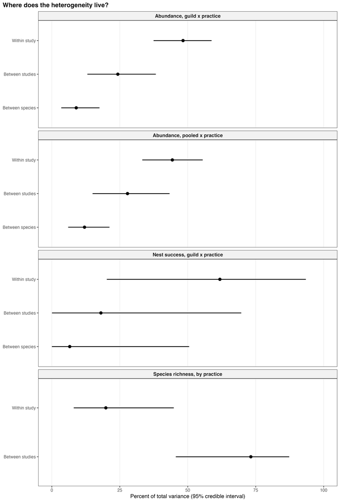

Table 17: Variance components by model and level.

| Model | Level | Tau | I-squared |
| --- | --- | --- | --- |
| Abundance, guild x practice | Within study (between effect sizes) | 0.47 (0.42, 0.52) | 48.3 (37.4, 58.8) |
| Abundance, guild x practice | Between studies | 0.33 (0.23, 0.46) | 24.3 (13.1, 38.3) |
| Abundance, guild x practice | Between species | 0.20 (0.13, 0.29) | 9.0 (3.5, 17.5) |
| Abundance, pooled x practice | Within study (between effect sizes) | 0.49 (0.45, 0.54) | 44.3 (33.3, 55.5) |
| Abundance, pooled x practice | Between studies | 0.39 (0.27, 0.54) | 27.8 (15.0, 43.3) |
| Abundance, pooled x practice | Between species | 0.26 (0.18, 0.35) | 12.0 (6.0, 21.2) |
| Nest success, guild x practice | Within study (between effect sizes) | 0.41 (0.27, 0.61) | 61.8 (20.2, 93.4) |
| Nest success, guild x practice | Between studies | 0.22 (0.01, 0.60) | 18.1 (0.1, 69.7) |
| Nest success, guild x practice | Between species | 0.14 (0.01, 0.48) | 6.6 (0.0, 50.5) |
| Species richness, by practice | Between studies | 0.96 (0.61, 1.39) | 73.2 (45.6, 87.3) |
| Species richness, by practice | Within study (between effect sizes) | 0.50 (0.35, 0.71) | 19.9 (8.1, 44.9) |

**How to read this.** These components separate real differences between studies from sampling noise. Where between-study variance dominates, a pooled mean describes the average study rather than a value any one site should expect.